# Lab 4 - Model selection

Ilaria Prosdocimi

Prendiamo in esame il dataset `prostate`:

```r
urlLocation <- "https://web.stanford.edu/~hastie/ElemStatLearn/datasets/prostate.data"
prostate <- read.table(urlLocation, header=TRUE)[,1:9]
## explanation of the data
## https://web.stanford.edu/~hastie/ElemStatLearn/datasets/prostate.info.txt
# write.csv("../data/prostate.csv")
```

```r
prostate <- read.csv("../data/prostate.csv", header=TRUE)[,1:9]
```

Le variabili nel dataset sono:

- lcavol: log cancer volume
- lweight: log prostate weight
- age: age of patient
- lbph: log of the amount of benign prostatic hyperplasia
- svi: seminal vesicle invasion (binary variable)
- lcp: log of capsular penetration
- gleason: Gleason score
- pgg45: percent of Gleason scores 4 or 5
- lpsa: log PSA score

Desideriamo costruire un modello che abbia `lpsa` come variabile risposta e una o più delle altre variabili come variabili esplicative: questo può essere utile sia per uno scopo predittivo (cioè stimare il valore di `lpsa` per un nuovo paziente) che per scopo inferenziale (cioè capire quali siano le variabili che hanno un effetto sul valore di `lpsa`).

Il grafico mostra la relazione di `lpsa` con tutte le altre variabili nel dataset (NB: questo tipo di analisi esplorativa è possibile solo se ci sono poche variabili nel dataset):

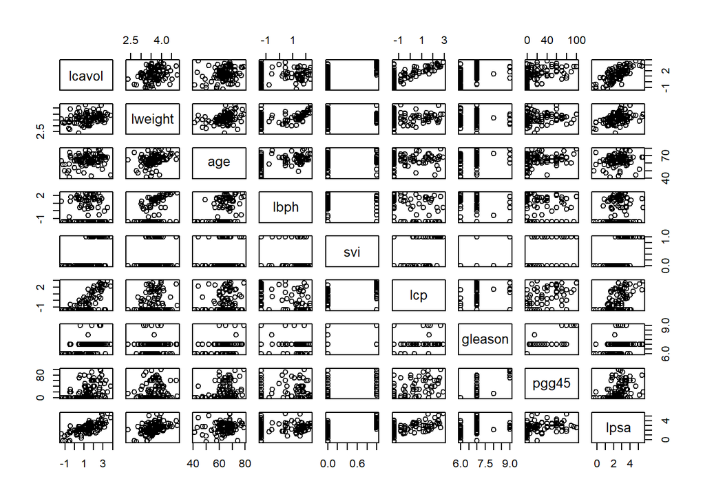

```r
plot(prostate)
```

# Model selection tramite algoritmi step-wise

I due estremi a cui si può pensare sono un modello che non includa nessun predittore (cioè un modello con solo l’intercetta) e un modello che includa tutti i predittori. Per poter fare la stima in maniera corretta dobbiamo trasformare la variabile `svi` da numerica ad una variabile `factor`, cioè una variabile categorica.

```r
prostate$svi <- as.factor(prostate$svi)
fit_int_only <- lm(lpsa~1,data = prostate)
fit_all_vars <- lm(lpsa~.,data = prostate)
```

La prima domanda che possiamo porci è se il modello più complesso sia *significativo*

```r
anova(fit_int_only, fit_all_vars)
```

```
## Analysis of Variance Table
##
## Model 1: lpsa ~ 1
## Model 2: lpsa ~ lcavol + lweight + age + lbph + svi + lcp + gleason +
##     pgg45
##   Res.Df     RSS Df Sum of Sq      F    Pr(>F)
## 1     96 127.918
## 2     88  43.058  8    84.859 21.679 < 2.2e-16 ***
## ---
## Signif. codes:  0 '***' 0.001 '**' 0.01 '*' 0.05 '.' 0.1 ' ' 1
```

Includere tutti i predittori sembra spiegare una buona parte della variabilità dei dati. Forse però esiste un modello che è una via di mezzo tra i due estremi e spiga una proporzione della variabilità dei dati comparabile con quella spiegata da `fit_all_vars` ma usando meno parametri. Per fare questa valutazione possiamo usare AIC, in cui la bontà di adattamento (misurata dalla verosimiglianza del modelli) viene penalizzata per il numero di gradi di libertà usati dal modello. Il valore di AIC per il modello con la sola intercetta è 306.1116269. Potremmo cercare di trovare il modello con un solo predittore che porta ad il più grande miglioramene in termini di AIC (cioè il valore di AIC minore):

```r
for(j in 1:(ncol(prostate)-1)) print(c(names(prostate)[j],AIC(lm(prostate$lpsa~prostate[,j]))))
```

```
## [1] "lcavol"           "232.908040520779"
## [1] "lweight"          "287.938884382005"
## [1] "age"             "305.28083171633"
## [1] "lbph"             "304.923660989906"
## [1] "svi"              "270.616301177566"
## [1] "lcp"              "273.348297964505"
## [1] "gleason"          "293.914939851134"
## [1] "pgg45"            "289.056791954584"
```

```r
## the lcavol variable is the one that reduces AIC the most
```

Il passo successivo sarebbe quello di controllare se esiste un modello che include due variabili esplicative per cui si riesce ad ottenere un valore di AIC ancora più piccolo. Invece che fare questo procedura manualmente usiamo la funzione `step` per eseguire un algoritmo di ricerca del modello in *forward search*, cioè una ricerca che parte da un modello piccolo e va via via ad aumentare la complessità del modello fino a che non è più possibile migliorare il valore di AIC aggiungendo predittori:

```r
fit_int_only <- lm(lpsa~1,data = prostate)
fit_all_vars <- lm(lpsa~.,data = prostate)
sel_forw <- step(object = fit_int_only, direction = "forward",
                 ## scope give the lower, i.e. simplest, and upper, most complex, limits
                 ## the "range" of models in which the algorithm will perform its search
     scope = list(lower=fit_int_only, upper = fit_all_vars))
```

```
## Start:  AIC=28.84
## lpsa ~ 1
##
##           Df Sum of Sq     RSS     AIC
## + lcavol   1    69.003  58.915 -44.366
## + svi      1    41.011  86.907  -6.658
## + lcp      1    38.528  89.389  -3.926
## + lweight  1    24.019 103.899  10.665
## + pgg45    1    22.814 105.103  11.783
## + gleason  1    17.416 110.502  16.641
## + lbph     1     4.136 123.782  27.650
## + age      1     3.679 124.239  28.007
## <none>                 127.918  28.838
##
## Step:  AIC=-44.37
## lpsa ~ lcavol
##
##           Df Sum of Sq    RSS     AIC
## + lweight  1    7.1726 51.742 -54.958
## + svi      1    5.2375 53.677 -51.397
## + lbph     1    3.2658 55.649 -47.898
## + pgg45    1    1.6980 57.217 -45.203
## <none>                 58.915 -44.366
## + lcp      1    0.6562 58.259 -43.452
## + gleason  1    0.4156 58.499 -43.053
## + age      1    0.0025 58.912 -42.370
##
## Step:  AIC=-54.96
## lpsa ~ lcavol + lweight
##
##           Df Sum of Sq    RSS     AIC
## + svi      1    5.1737 46.568 -63.177
## + pgg45    1    1.8158 49.926 -56.424
## <none>                 51.742 -54.958
## + lcp      1    0.8187 50.923 -54.506
## + gleason  1    0.7163 51.026 -54.311
## + age      1    0.6456 51.097 -54.176
## + lbph     1    0.4440 51.298 -53.794
##
## Step:  AIC=-63.18
```

[output cut: 13 more lines]

```
##           Df Sum of Sq    RSS     AIC
## + age      1   1.15879 44.437 -63.723
## <none>                 45.595 -63.226
## + pgg45    1   0.33173 45.264 -61.934
## + gleason  1   0.20691 45.389 -61.667
## + lcp      1   0.10115 45.494 -61.441
##
## Step:  AIC=-63.72
## lpsa ~ lcavol + lweight + svi + lbph + age
##
##           Df Sum of Sq    RSS     AIC
## <none>                 44.437 -63.723
## + pgg45    1   0.66071 43.776 -63.176
## + gleason  1   0.47674 43.960 -62.769
## + lcp      1   0.13040 44.306 -62.008
```

Dopo 5 iterazioni l’algoritmo si ferma e identifica un modello che include le variabili:

```r
names(sel_forw$coefficients)
```

```
## [1] "(Intercept)" "lcavol"      "lweight"     "svi1"        "lbph"
## [6] "age"
```

Aggiungere un altra variabile esplicativa non porta a miglioramenti del valore di AIC. Notiamo immediatamente che il valore di AIC per il modello individuato (213.5514441) è di molto minore al valore di AIC del modello con la sola intercetta.

AIC viene calcolato con:
$$AIC(M) = - 2 *
logLik(M) + 2 * p(M)$$
dove $p(M)$ è il numero di gradi di libertà del modello $M$.

In R questo si può derivare con:

```r
-2*as.numeric(logLik(sel_forw)) + 2*(length(sel_forw$coefficients)+1)
```

```
## [1] 213.5514
```

```r
## or more simply
AIC(sel_forw)
```

```
## [1] 213.5514
```

```r
### step uses the MSS based definition
nrow(sel_forw$model)*log(mean(sel_forw$residuals^2)) + 2*(length(sel_forw$coefficients))
```

```
## [1] -63.72263
```

```r
## it's OK to use slightly different definition up or minus a constant, since what matters is the ranking
```

Un altro possibile approccio è quello di usare un algoritmo di *backward search*, in cui si parte da un modello complesso e si va via via a togliere un variabile alla volta fino a che si continua a diminuire il valore di AIC:

```r
sel_back <- step(object = fit_all_vars, direction = "backward",
     scope = list(lower=fit_int_only, upper = fit_all_vars))
```

```
## Start:  AIC=-60.78
## lpsa ~ lcavol + lweight + age + lbph + svi + lcp + gleason +
##     pgg45
##
##           Df Sum of Sq    RSS     AIC
## - gleason  1    0.0491 43.108 -62.668
## - pgg45    1    0.5102 43.569 -61.636
## - lcp      1    0.6814 43.740 -61.256
## <none>                 43.058 -60.779
## - lbph     1    1.3646 44.423 -59.753
## - age      1    1.7981 44.857 -58.810
## - lweight  1    4.6907 47.749 -52.749
## - svi      1    4.8803 47.939 -52.364
## - lcavol   1   20.1994 63.258 -25.467
##
## Step:  AIC=-62.67
## lpsa ~ lcavol + lweight + age + lbph + svi + lcp + pgg45
##
##           Df Sum of Sq    RSS     AIC
## - lcp      1    0.6684 43.776 -63.176
## <none>                 43.108 -62.668
## - pgg45    1    1.1987 44.306 -62.008
## - lbph     1    1.3844 44.492 -61.602
## - age      1    1.7579 44.865 -60.791
## - lweight  1    4.6429 47.751 -54.746
## - svi      1    4.8333 47.941 -54.360
## - lcavol   1   21.3191 64.427 -25.691
##
## Step:  AIC=-63.18
## lpsa ~ lcavol + lweight + age + lbph + svi + pgg45
##
##           Df Sum of Sq    RSS     AIC
## - pgg45    1    0.6607 44.437 -63.723
## <none>                 43.776 -63.176
## - lbph     1    1.3329 45.109 -62.266
## - age      1    1.4878 45.264 -61.934
## - svi      1    4.1766 47.953 -56.336
## - lweight  1    4.6553 48.431 -55.373
## - lcavol   1   22.7555 66.531 -24.572
##
## Step:  AIC=-63.72
## lpsa ~ lcavol + lweight + age + lbph + svi
##
##           Df Sum of Sq    RSS     AIC
## <none>                 44.437 -63.723
## - age      1    1.1588 45.595 -63.226
## - lbph     1    1.5087 45.945 -62.484
## - lweight  1    4.3140 48.751 -56.735
## - svi      1    5.8509 50.288 -53.724
## - lcavol   1   25.9427 70.379 -21.119
```

Per questo dataset i due algoritmi trovano lo stesso modello (non sempre è così).

L’ultimo approccio possibile è l’approccio *stepwise* in cui ad ogni iterazione l’algoritmo verifica se aggiungere o togliere una variabile migliora il valore di AIC. L’algoritmo può essere inizializzato con modelli molto semplici, complessi, o intermedi:

```r
sel_both <- step(object = fit_int_only, direction = "both",
     scope = list(lower=fit_int_only, upper = fit_all_vars))
```

```
## Start:  AIC=28.84
## lpsa ~ 1
##
##           Df Sum of Sq     RSS     AIC
## + lcavol   1    69.003  58.915 -44.366
## + svi      1    41.011  86.907  -6.658
## + lcp      1    38.528  89.389  -3.926
## + lweight  1    24.019 103.899  10.665
## + pgg45    1    22.814 105.103  11.783
## + gleason  1    17.416 110.502  16.641
## + lbph     1     4.136 123.782  27.650
## + age      1     3.679 124.239  28.007
## <none>                 127.918  28.838
##
## Step:  AIC=-44.37
## lpsa ~ lcavol
##
##           Df Sum of Sq     RSS     AIC
## + lweight  1     7.173  51.742 -54.958
## + svi      1     5.237  53.677 -51.397
## + lbph     1     3.266  55.649 -47.898
## + pgg45    1     1.698  57.217 -45.203
## <none>                  58.915 -44.366
## + lcp      1     0.656  58.259 -43.452
## + gleason  1     0.416  58.499 -43.053
## + age      1     0.003  58.912 -42.370
## - lcavol   1    69.003 127.918  28.838
##
## Step:  AIC=-54.96
## lpsa ~ lcavol + lweight
##
##           Df Sum of Sq     RSS     AIC
## + svi      1     5.174  46.568 -63.177
## + pgg45    1     1.816  49.926 -56.424
## <none>                  51.742 -54.958
## + lcp      1     0.819  50.923 -54.506
## + gleason  1     0.716  51.026 -54.311
## + age      1     0.646  51.097 -54.176
## + lbph     1     0.444  51.298 -53.794
## - lweight  1     7.173  58.915 -44.366
```

[output cut: 28 more lines]

```
## - lcavol   1   24.9384 70.534 -22.906
##
## Step:  AIC=-63.72
## lpsa ~ lcavol + lweight + svi + lbph + age
##
##           Df Sum of Sq    RSS     AIC
## <none>                 44.437 -63.723
## - age      1    1.1588 45.595 -63.226
## + pgg45    1    0.6607 43.776 -63.176
## + gleason  1    0.4767 43.960 -62.769
## - lbph     1    1.5087 45.945 -62.484
## + lcp      1    0.1304 44.306 -62.008
## - lweight  1    4.3140 48.751 -56.735
## - svi      1    5.8509 50.288 -53.724
## - lcavol   1   25.9427 70.379 -21.119
```

```r
sel_both_bis <- step(object = fit_all_vars, direction = "both",
     scope = list(lower=fit_int_only, upper = fit_all_vars))
```

```
## Start:  AIC=-60.78
## lpsa ~ lcavol + lweight + age + lbph + svi + lcp + gleason +
##     pgg45
##
##           Df Sum of Sq    RSS     AIC
## - gleason  1    0.0491 43.108 -62.668
## - pgg45    1    0.5102 43.569 -61.636
## - lcp      1    0.6814 43.740 -61.256
## <none>                 43.058 -60.779
## - lbph     1    1.3646 44.423 -59.753
## - age      1    1.7981 44.857 -58.810
## - lweight  1    4.6907 47.749 -52.749
## - svi      1    4.8803 47.939 -52.364
## - lcavol   1   20.1994 63.258 -25.467
##
## Step:  AIC=-62.67
## lpsa ~ lcavol + lweight + age + lbph + svi + lcp + pgg45
##
##           Df Sum of Sq    RSS     AIC
## - lcp      1    0.6684 43.776 -63.176
## <none>                 43.108 -62.668
## - pgg45    1    1.1987 44.306 -62.008
## - lbph     1    1.3844 44.492 -61.602
## - age      1    1.7579 44.865 -60.791
## + gleason  1    0.0491 43.058 -60.779
## - lweight  1    4.6429 47.751 -54.746
## - svi      1    4.8333 47.941 -54.360
## - lcavol   1   21.3191 64.427 -25.691
##
## Step:  AIC=-63.18
## lpsa ~ lcavol + lweight + age + lbph + svi + pgg45
##
##           Df Sum of Sq    RSS     AIC
## - pgg45    1    0.6607 44.437 -63.723
## <none>                 43.776 -63.176
## + lcp      1    0.6684 43.108 -62.668
## - lbph     1    1.3329 45.109 -62.266
## - age      1    1.4878 45.264 -61.934
## + gleason  1    0.0362 43.740 -61.256
## - svi      1    4.1766 47.953 -56.336
## - lweight  1    4.6553 48.431 -55.373
## - lcavol   1   22.7555 66.531 -24.572
##
## Step:  AIC=-63.72
## lpsa ~ lcavol + lweight + age + lbph + svi
##
##           Df Sum of Sq    RSS     AIC
## <none>                 44.437 -63.723
## - age      1    1.1588 45.595 -63.226
## + pgg45    1    0.6607 43.776 -63.176
## + gleason  1    0.4767 43.960 -62.769
## - lbph     1    1.5087 45.945 -62.484
## + lcp      1    0.1304 44.306 -62.008
## - lweight  1    4.3140 48.751 -56.735
## - svi      1    5.8509 50.288 -53.724
## - lcavol   1   25.9427 70.379 -21.119
```

```r
### regardless of where we start we find the same model
identical(sort(names(sel_both$coefficients)),
          sort(names(sel_both_bis$coefficients)))
```

```
## [1] TRUE
```

```r
sel_both_intermediate <- step(object = lm(lpsa ~ lcavol + gleason, data = prostate),
                              direction = "both",
     scope = list(lower=fit_int_only, upper = fit_all_vars))
```

```
## Start:  AIC=-43.05
## lpsa ~ lcavol + gleason
##
##           Df Sum of Sq     RSS     AIC
## + lweight  1     7.473  51.026 -54.311
## + svi      1     4.969  53.530 -49.664
## + lbph     1     3.114  55.385 -46.359
## - gleason  1     0.416  58.915 -44.366
## + pgg45    1     1.414  57.086 -43.425
## <none>                  58.499 -43.053
## + lcp      1     0.398  58.102 -41.714
## + age      1     0.006  58.493 -41.063
## - lcavol   1    52.002 110.502  16.641
##
## Step:  AIC=-54.31
## lpsa ~ lcavol + gleason + lweight
##
##           Df Sum of Sq    RSS     AIC
## + svi      1     4.802 46.224 -61.898
## - gleason  1     0.716 51.742 -54.958
## + pgg45    1     1.115 49.910 -54.455
## + age      1     1.051 49.975 -54.329
## <none>                 51.026 -54.311
## + lcp      1     0.436 50.590 -53.143
## + lbph     1     0.323 50.702 -52.927
## - lweight  1     7.473 58.499 -43.053
## - lcavol   1    37.657 88.683  -2.696
##
## Step:  AIC=-61.9
## lpsa ~ lcavol + gleason + lweight + svi
##
##           Df Sum of Sq    RSS     AIC
## - gleason  1    0.3445 46.568 -63.177
## <none>                 46.224 -61.898
## + age      1    0.9049 45.319 -61.815
## + lbph     1    0.8354 45.389 -61.667
## + lcp      1    0.2271 45.997 -60.375
## + pgg45    1    0.1733 46.051 -60.262
## - svi      1    4.8019 51.026 -54.311
## - lweight  1    7.3060 53.530 -49.664
```

[output cut: 28 more lines]

```
## - lcavol   1   24.9384 70.534 -22.906
##
## Step:  AIC=-63.72
## lpsa ~ lcavol + lweight + svi + lbph + age
##
##           Df Sum of Sq    RSS     AIC
## <none>                 44.437 -63.723
## - age      1    1.1588 45.595 -63.226
## + pgg45    1    0.6607 43.776 -63.176
## + gleason  1    0.4767 43.960 -62.769
## - lbph     1    1.5087 45.945 -62.484
## + lcp      1    0.1304 44.306 -62.008
## - lweight  1    4.3140 48.751 -56.735
## - svi      1    5.8509 50.288 -53.724
## - lcavol   1   25.9427 70.379 -21.119
```

In questo esempio tutti e tre gli approcci portano alla scelta dello stesso modello:

```r
identical(sort(names(sel_back$coefficients)),
          sort(names(sel_forw$coefficients)))
```

```
## [1] TRUE
```

```r
identical(sort(names(sel_back$coefficients)),
          sort(names(sel_both_bis$coefficients)))
```

```
## [1] TRUE
```

Possiamo ora controllare come il modello si adatta ai dati:

```r
summary(sel_back)
```

```
##
## Call:
## lm(formula = lpsa ~ lcavol + lweight + age + lbph + svi, data = prostate)
##
## Residuals:
##      Min       1Q   Median       3Q      Max
## -1.86717 -0.37725  0.01257  0.40252  1.44544
##
## Coefficients:
##             Estimate Std. Error t value Pr(>|t|)
## (Intercept)  0.49473    0.87652   0.564  0.57385
## lcavol       0.54400    0.07463   7.289 1.11e-10 ***
## lweight      0.58821    0.19790   2.972  0.00378 **
## age         -0.01644    0.01068  -1.540  0.12692
## lbph         0.10122    0.05759   1.758  0.08215 .
## svi1         0.71490    0.20653   3.461  0.00082 ***
## ---
## Signif. codes:  0 '***' 0.001 '**' 0.01 '*' 0.05 '.' 0.1 ' ' 1
##
## Residual standard error: 0.6988 on 91 degrees of freedom
## Multiple R-squared:  0.6526, Adjusted R-squared:  0.6335
## F-statistic: 34.19 on 5 and 91 DF,  p-value: < 2.2e-16
```

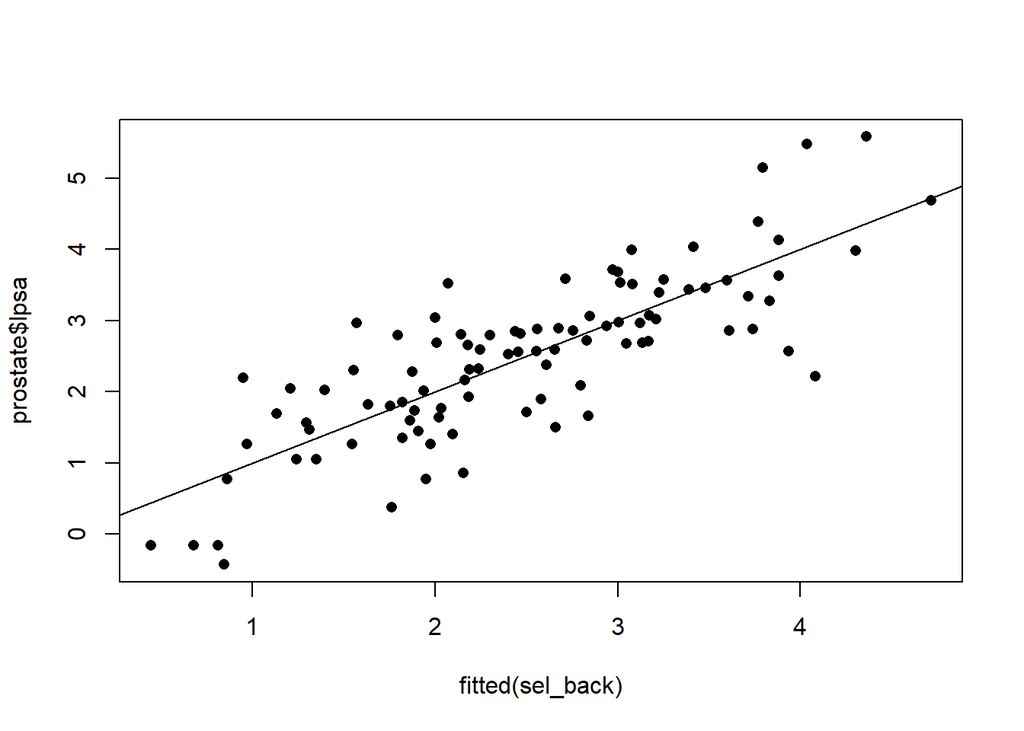

```r
plot(fitted(sel_back),prostate$lpsa, pch=16)
abline(0,1) ## not bad
```

Il modello è significativo contro il modello nullo e spiega una buona proporzione dei dati. Quando invece confrontiamo il modello selezionato con il modello più complesso non vediamo una differenza significativa nel valore di variabilità spiegato:

```r
anova(sel_back, fit_all_vars)
```

```
## Analysis of Variance Table
##
## Model 1: lpsa ~ lcavol + lweight + age + lbph + svi
## Model 2: lpsa ~ lcavol + lweight + age + lbph + svi + lcp + gleason +
##     pgg45
##   Res.Df    RSS Df Sum of Sq      F Pr(>F)
## 1     91 44.437
## 2     88 43.058  3    1.3783 0.9389 0.4254
```

Fino ad ora abbiamo usato il valore di AIC per decidere quali variabili includere nel modello. Possiamo anche usare il valore di BIC, in cui la penalizzazione della complessità del modello è più forte (specie quando $n$ è grande) dato che la sua forma è:

Confrontiamo AIC e BIC per i modelli ai due estremi della complessità:

```r
AIC(fit_all_vars); AIC(fit_int_only)
```

```
## [1] 216.4952
```

```
## [1] 306.1116
```

```r
BIC(fit_all_vars); BIC(fit_int_only)
```

```
## [1] 242.2423
```

```
## [1] 311.261
```

```r
## alternatively AIC(fit_int_only, k=log(nrow(prostate)))
```

Possiamo ancora usare la funzione step `step` per fare model selection cercando modelli che minimizzino il valore di BIC:

```r
sel_bic_back <- step(object = fit_all_vars, direction = "backward",
     scope = list(lower=fit_int_only, upper = fit_all_vars),k=log(nrow(prostate)))
```

```
## Start:  AIC=-37.61
## lpsa ~ lcavol + lweight + age + lbph + svi + lcp + gleason +
##     pgg45
##
##           Df Sum of Sq    RSS     AIC
## - gleason  1    0.0491 43.108 -42.071
## - pgg45    1    0.5102 43.569 -41.039
## - lcp      1    0.6814 43.740 -40.658
## - lbph     1    1.3646 44.423 -39.155
## - age      1    1.7981 44.857 -38.213
## <none>                 43.058 -37.606
## - lweight  1    4.6907 47.749 -32.151
## - svi      1    4.8803 47.939 -31.767
## - lcavol   1   20.1994 63.258  -4.869
##
## Step:  AIC=-42.07
## lpsa ~ lcavol + lweight + age + lbph + svi + lcp + pgg45
##
##           Df Sum of Sq    RSS     AIC
## - lcp      1    0.6684 43.776 -45.153
## - pgg45    1    1.1987 44.306 -43.985
## - lbph     1    1.3844 44.492 -43.579
## - age      1    1.7579 44.865 -42.768
## <none>                 43.108 -42.071
## - lweight  1    4.6429 47.751 -36.723
## - svi      1    4.8333 47.941 -36.337
## - lcavol   1   21.3191 64.427  -7.668
##
## Step:  AIC=-45.15
## lpsa ~ lcavol + lweight + age + lbph + svi + pgg45
##
##           Df Sum of Sq    RSS     AIC
## - pgg45    1    0.6607 44.437 -48.274
## - lbph     1    1.3329 45.109 -46.818
## - age      1    1.4878 45.264 -46.486
## <none>                 43.776 -45.153
## - svi      1    4.1766 47.953 -40.888
## - lweight  1    4.6553 48.431 -39.924
## - lcavol   1   22.7555 66.531  -9.124
##
```

[output cut: 14 more lines]

```
##           Df Sum of Sq    RSS     AIC
## - lbph     1    0.9730 46.568 -52.879
## <none>                 45.595 -50.352
## - lweight  1    3.6907 49.286 -47.377
## - svi      1    5.7027 51.298 -43.496
## - lcavol   1   24.9384 70.534 -12.607
##
## Step:  AIC=-52.88
## lpsa ~ lcavol + lweight + svi
##
##           Df Sum of Sq    RSS     AIC
## <none>                 46.568 -52.879
## - svi      1    5.1737 51.742 -47.234
## - lweight  1    7.1089 53.677 -43.673
## - lcavol   1   24.7058 71.274 -16.169
```

```r
sel_bic_forw <- step(object = fit_int_only, direction = "forward",
     scope = list(lower=fit_int_only, upper = fit_all_vars),k=log(nrow(prostate)))
```

```
## Start:  AIC=31.41
## lpsa ~ 1
##
##           Df Sum of Sq     RSS     AIC
## + lcavol   1    69.003  58.915 -39.217
## + svi      1    41.011  86.907  -1.508
## + lcp      1    38.528  89.389   1.224
## + lweight  1    24.019 103.899  15.814
## + pgg45    1    22.814 105.103  16.932
## + gleason  1    17.416 110.502  21.790
## <none>                 127.918  31.412
## + lbph     1     4.136 123.782  32.799
## + age      1     3.679 124.239  33.156
##
## Step:  AIC=-39.22
## lpsa ~ lcavol
##
##           Df Sum of Sq    RSS     AIC
## + lweight  1    7.1726 51.742 -47.234
## + svi      1    5.2375 53.677 -43.673
## + lbph     1    3.2658 55.649 -40.174
## <none>                 58.915 -39.217
## + pgg45    1    1.6980 57.217 -37.479
## + lcp      1    0.6562 58.259 -35.728
## + gleason  1    0.4156 58.499 -35.329
## + age      1    0.0025 58.912 -34.646
##
## Step:  AIC=-47.23
## lpsa ~ lcavol + lweight
##
##           Df Sum of Sq    RSS     AIC
## + svi      1    5.1737 46.568 -52.879
## <none>                 51.742 -47.234
## + pgg45    1    1.8158 49.926 -46.125
## + lcp      1    0.8187 50.923 -44.207
## + gleason  1    0.7163 51.026 -44.012
## + age      1    0.6456 51.097 -43.878
## + lbph     1    0.4440 51.298 -43.496
##
## Step:  AIC=-52.88
## lpsa ~ lcavol + lweight + svi
##
##           Df Sum of Sq    RSS     AIC
## <none>                 46.568 -52.879
## + lbph     1   0.97296 45.595 -50.352
## + age      1   0.62301 45.945 -49.610
## + pgg45    1   0.50069 46.068 -49.352
## + gleason  1   0.34449 46.224 -49.024
## + lcp      1   0.06937 46.499 -48.448
```

```r
sel_bic_both <- step(object = fit_all_vars, direction = "both",
     scope = list(lower=fit_int_only, upper = fit_all_vars),k=log(nrow(prostate)))
```

```
## Start:  AIC=-37.61
## lpsa ~ lcavol + lweight + age + lbph + svi + lcp + gleason +
##     pgg45
##
##           Df Sum of Sq    RSS     AIC
## - gleason  1    0.0491 43.108 -42.071
## - pgg45    1    0.5102 43.569 -41.039
## - lcp      1    0.6814 43.740 -40.658
## - lbph     1    1.3646 44.423 -39.155
## - age      1    1.7981 44.857 -38.213
## <none>                 43.058 -37.606
## - lweight  1    4.6907 47.749 -32.151
## - svi      1    4.8803 47.939 -31.767
## - lcavol   1   20.1994 63.258  -4.869
##
## Step:  AIC=-42.07
## lpsa ~ lcavol + lweight + age + lbph + svi + lcp + pgg45
##
##           Df Sum of Sq    RSS     AIC
## - lcp      1    0.6684 43.776 -45.153
## - pgg45    1    1.1987 44.306 -43.985
## - lbph     1    1.3844 44.492 -43.579
## - age      1    1.7579 44.865 -42.768
## <none>                 43.108 -42.071
## + gleason  1    0.0491 43.058 -37.606
## - lweight  1    4.6429 47.751 -36.723
## - svi      1    4.8333 47.941 -36.337
## - lcavol   1   21.3191 64.427  -7.668
##
## Step:  AIC=-45.15
## lpsa ~ lcavol + lweight + age + lbph + svi + pgg45
##
##           Df Sum of Sq    RSS     AIC
## - pgg45    1    0.6607 44.437 -48.274
## - lbph     1    1.3329 45.109 -46.818
## - age      1    1.4878 45.264 -46.486
## <none>                 43.776 -45.153
## + lcp      1    0.6684 43.108 -42.071
## - svi      1    4.1766 47.953 -40.888
## + gleason  1    0.0362 43.740 -40.658
```

[output cut: 29 more lines]

```
## - lcavol   1   24.9384 70.534 -12.607
##
## Step:  AIC=-52.88
## lpsa ~ lcavol + lweight + svi
##
##           Df Sum of Sq    RSS     AIC
## <none>                 46.568 -52.879
## + lbph     1    0.9730 45.595 -50.352
## + age      1    0.6230 45.945 -49.610
## + pgg45    1    0.5007 46.068 -49.352
## + gleason  1    0.3445 46.224 -49.024
## + lcp      1    0.0694 46.499 -48.448
## - svi      1    5.1737 51.742 -47.234
## - lweight  1    7.1089 53.677 -43.673
## - lcavol   1   24.7058 71.274 -16.169
```

# Validazione incrociata: Leave-one-out cross validation

Un approccio diverso alla model selection è quello di usare la validazione incrociata o leave-one-out cross-validation. L’idea è quella di valutare i modelli considerando la loro variabilità quando usati per predire nuove osservazioni (modelli troppo complessi e sovra-parametrizzati tenderanno ad essere poco generalizzabili e a fare predizioni molto variabili). Quindi invece che usare solo misure di bontà di adattamento *in-sample* (in cui usiamo lo stesso campione per stimare e valutare il modello) si definisce una quantità che misuri la capacità del modello di essere affidabile *out-of-sample* usando parti diverse del campione per stimare il modello e valutarne la bontà di adattamento. In particolare si quantifica l’errore che possiamo aspettarci di fare quando si usa un modello stimato per predire una nuova osservazione calcolando il leave-one-out error $e[i] = y_i - \hat{y}[i]$, dove $\hat{y}[i]$ indica il valore per l’osservazione $i$ ottenuta con un modello stimato senza usare l’osservazione $i$.

Esemplifichiamo la cosa usando il modello `sel_bic_both`:

```r
i = 1 ; X <- model.matrix(sel_bic_both)
esqi <- prostate$lpsa[i] -  X[i,]%*%lm(lpsa ~ lcavol + lweight + svi, data = prostate[-i,])$coef
esqi
```

```
##           [,1]
## [1,] -1.266671
```

Il valore di $RMSE_{LOOCV}$ viene calcolato con:

```r
esq <- rep(NA,length = nrow(prostate))
for(i in seq_along(esq)){
  esq[i] <- prostate$lpsa[i] -  X[i,]%*%lm(lpsa ~ lcavol + lweight + svi, data = prostate[-i,])$coef
}
sqrt(mean(esq^2))
```

```
## [1] 0.7249328
```

Per i modelli lineari tuttavia, si può dimostrare che il valore di $RMSE_{LOOCV}$ può essere derivato senza dover stimare effettivamente il modello $n$ volte usando la seguente formula:

$$\text{RMSE}_{\text{LOOCV}} = \sqrt{\frac{1}{n}\sum_{i=1}^n
\left(\frac{e_{i}}{1-h_{ii}}\right)^2},$$

dove $h_{ii}$ sono gli elementi diagonali della matrice cappello (hat matrix):

```r
calc_loocv_rmse = function(model) {
  sqrt(mean((resid(model) / (1 - hatvalues(model))) ^ 2))
}
calc_loocv_rmse(sel_bic_both)
```

```
## [1] 0.7249328
```

Da dove vengono gli `hatvalues`?

```r
head(hatvalues(sel_bic_both))
```

```
##          1          2          3          4          5          6
## 0.06726174 0.05625576 0.07239334 0.06579229 0.01502927 0.05985106
```

```r
H <- X %*% solve(crossprod(X)) %*% t(X)
head(diag(H))
```

```
##          1          2          3          4          5          6
## 0.06726174 0.05625576 0.07239334 0.06579229 0.01502927 0.05985106
```

Ora possiamo quindi usare la funzione `calc_loocv_rmse` per confrontare alcuni dei modelli che abbiamo usato fino ad ora:

```r
calc_loocv_rmse(sel_back)
```

```
## [1] 0.7250511
```

```r
calc_loocv_rmse(sel_bic_back)
```

```
## [1] 0.7249328
```

```r
calc_loocv_rmse(fit_all_vars)
```

```
## [1] 0.7357507
```

`sel_bic_back` è il modello con il valore di $RMSE_{LOOCV}$ più basso.

# Verifica delle assunzioni del modello

Abbiamo individuato alcuni modelli ottimali: a seconda dell’approccio usato abbiamo identificato modelli diversi. Questo mostra come sia difficile identificare un modello “giusto” (spesso poi non esiste un modello vero, ma modelli competitivi tra loro). Tuttavia, per qualunque modello che possa essere stato identificato come ottimale da qualche criterio è poi necessario valutare la validità delle assunzioni sotto a cui sono derivate le stime del modello stesso (e su cui si fondano le quantità usate per valutare la bontà di adattamento). Queste assunzioni sono:

- Linearità (della relazione tra le X e la variabile risposta);
- Indipendenza (delle osservazioni/errori tra loro);
- Normalità degli errori;
- Eguaglianza delle varianze (Omoschedasticità)

Verifichiamo queste assunzioni per il modello `sel_bic_both`.

- Linearità ed eguaglianza delle varianze

La relazione tra i predittori e la variabile risposta è lineare? O, per dirla in altro modo, dopo che è stata stimata la relazione lineare tra il predittore e la variabile risposta, resta della relazione con una forma strutturata tra il predittore e i residui? E la forma tra i valori stimati e i residui è una variabile casuale o rimane una forma che indica che non abbiamo catturato qualche relazione strutturale nei dati?

Iniziamo con un grafico di ciascun predittore contro i residui:

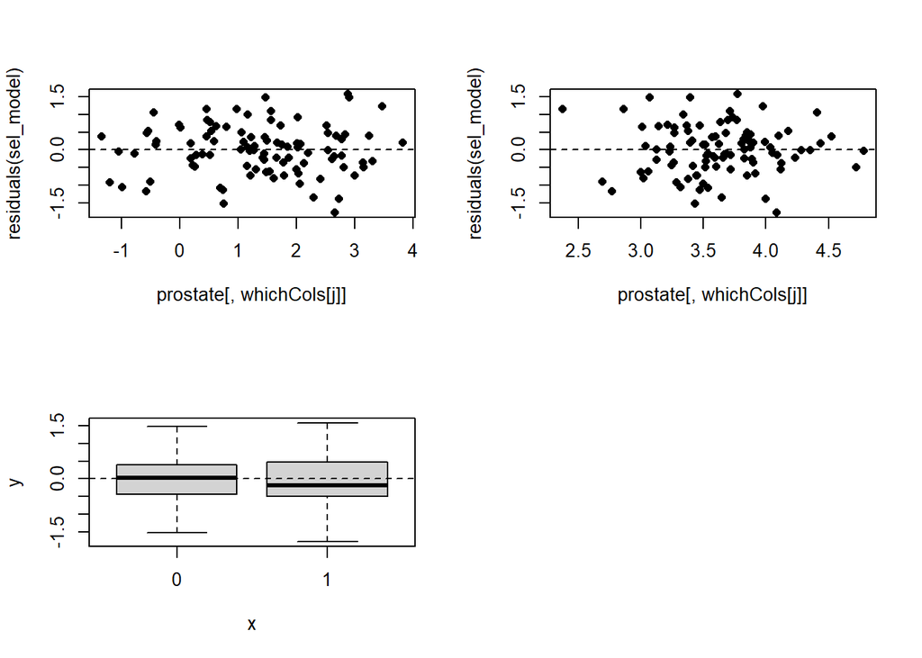

```r
sel_model <- sel_bic_both
whichCols <- names(sel_bic_both$coefficients)[-1]
if(any(whichCols == "svi1")) whichCols[whichCols == "svi1"] <- "svi"
par(mfrow=c(2,ceiling(length(whichCols)/2)),pch=16)
for(j in seq_along(whichCols)){
 plot(prostate[,whichCols[j]], residuals(sel_model))
  abline(h=0,lty=2)
}
```

A seguire il grafico dei valori stimati contro i residui:

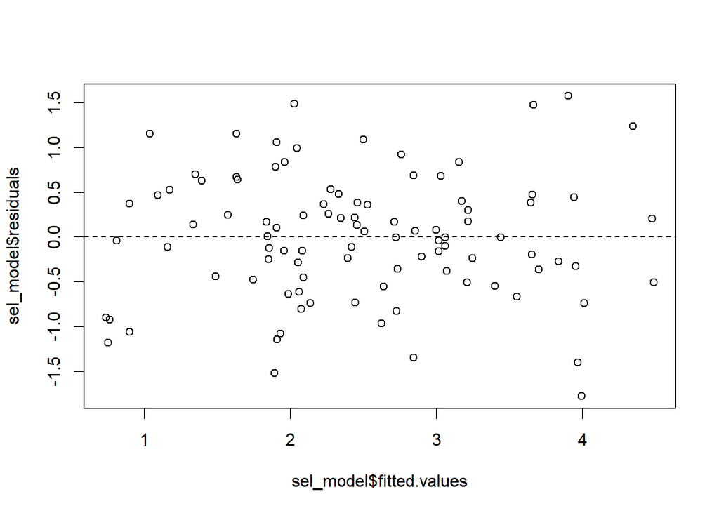

```r
plot(sel_model$fitted.values, sel_model$residuals)
abline(h=0,lty=2)
```

```r
# can also be derived with
# plot(sel_model,which=1)
```

Un altro grafico utile può essere quello, prodotto di default da R usando `plot`, in cui confrontiamo i valori stimati con una trasformazione dei residui che si presta bene a evidenziare possibili problemi di eteroschedasticità: $\sqrt{|std.residuals|}$

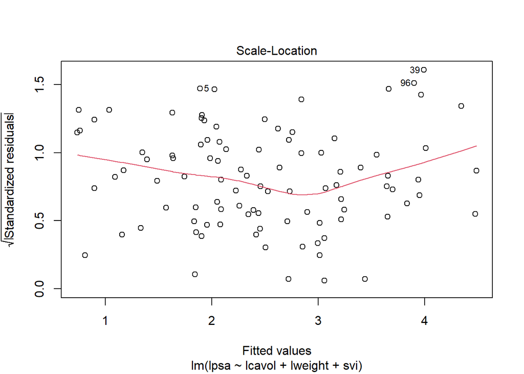

```r
plot(sel_model,which=3)
```

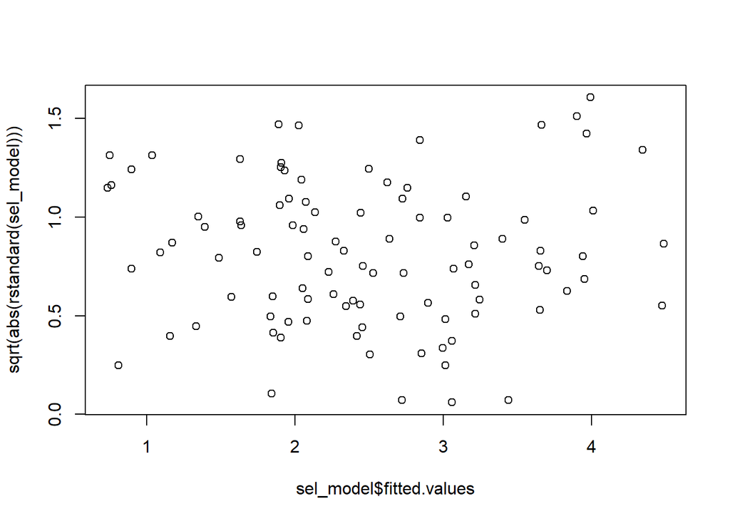

```r
plot(sel_model$fitted.values, sqrt(abs(rstandard(sel_model))))
```

Parleremo più in dettaglio dei residui standardizzati più avanti nel corso.

Questi grafici permettono anche di identificare possibili problemi con l’assunzione di omoschedasticità (varianze uguali).

Per il modello `sel_bic_both` non identifichiamo problemi rilevanti.

- Normalità

Ora controlliamo la normalità tramite un qqplot:

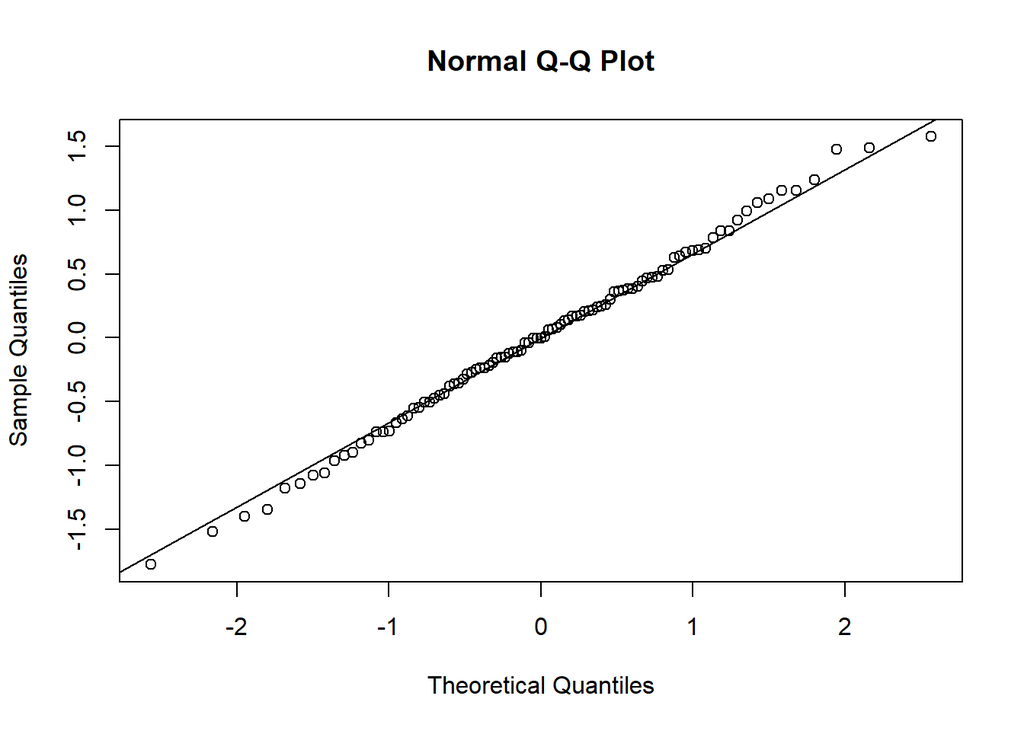

```r
qqnorm(sel_model$residuals)
qqline(sel_model$residuals)
```

```r
# can also be derived with
# plot(sel_model,which=2)
```

Il qqplot non mostra deviazioni di rilievo.

Valutare l’indipendenza delle osservazioni (e meglio, degli errori) è una cosa che non è facile fare con test o grafici. Possiamo considerare lo schema di campionamento e valutare se è credibile che le osservazioni siano indipendenti tra loro. Nel nostro dataset le osservazioni sono pazienti che hanno subito un intervento in un ospedale, e quindi non c’è una ragione evidente per cui si possa pensare che le misurazioni sui diversi pazienti siano dipendenti. Non sappiamo però ad esempio se alcuni dei pazienti sono legati da legami di parentela (e possano quindi avere delle caratteristiche comuni) o se siano parte di una popolazione esposta a qualche particolare forma di inquinamento che potrebbe portare a relazioni tra le variabili diverse da quelle della popolazione generale. Se invece i pazienti fossero stati osservati in ospedali diversi potremmo anche dover controllare se i pazienti nello stesso ospedale sono più simili tra loro dato che sono valutati dallo stesso personale medico usando le stesse strumentazioni. Dato che non abbiamo tutte queste informazioni teniamo per buona l’assunzione di indipendenza tra le osservazioni.

## Il qqplot

Il qqplot permette di confrontare la distribuzione dei residui contro quella di una normale. Cosa mostra esattamente il grafico? L’idea di base è di confrontare il campione osservato (ordinato) contro il campione teorico di dimensione $n$ che potremmo aspettarci di estrarre da una distribuzione normale. Che forma ha questo campione teorico/ideale da una normale? Possiamo pensare di estrarre il valore dei quantili di una normale legate alle probabilità $(1,\ldots,n)/(n+1)$, cioè derivare i quantili legati a probabilità distribuite uniformemente tra 0 e 1:

```r
## empirical quantiles
n <- nrow(sel_model$model)
head(sort(sel_model$residuals))
```

```
##        39         5        47        18         1         7
## -1.777446 -1.517854 -1.398234 -1.348380 -1.181472 -1.143684
```

```r
## theoretical quantiles under the standard normal
head(qnorm(seq(1,n)/(n+1)))
```

```
## [1] -2.318758 -2.045391 -1.871871 -1.741291 -1.635039 -1.544575
```

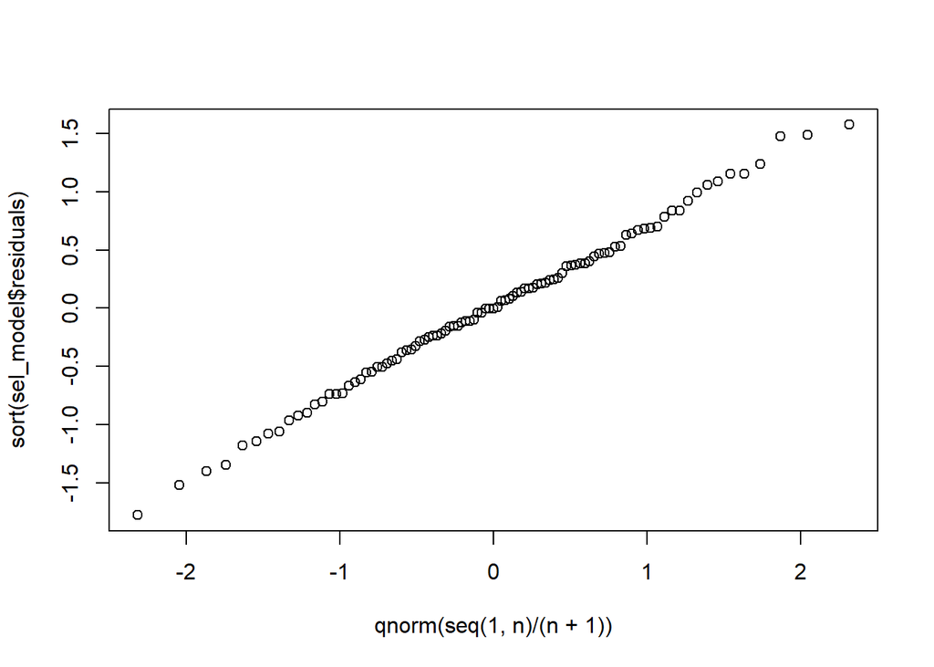

```r
plot(qnorm(seq(1,n)/(n+1)),
     sort(sel_model$residuals))
```

Ci sono diversi modi di ottenere la divisione dello spazio tra 0 e 1 in parti uguali e questo può influenzare l’aspetto del qqplot (in particolare quando la dimensionalità campionaria è piccola). La formula per dividere lo spazio della probabilità si scrive in maniera generale con
$$\frac{i-a}{n+1-2a}$$
individuando le cosiddette *plotting positions* - in `?ppoints` sono dati alcuni dettagli su come R implementa questo calcolo. Di default se $n>10$ si ha $a=0.5$, e quindi:

$$\frac{i-0.5}{n}$$

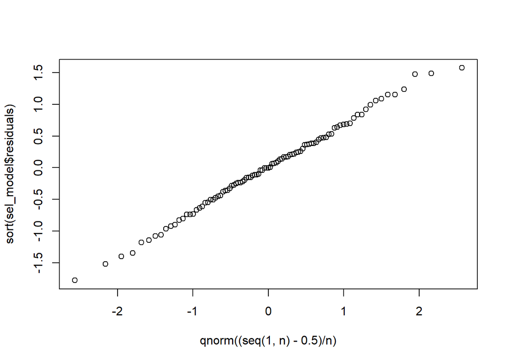

```r
plot(qnorm((seq(1,n)-0.5)/n),
     sort(sel_model$residuals))
```

# Categorical predictors

Uno dei predittori nel dataset non è numerico ma è una variabile dicotomica

- svi: seminal vesicle invasion (binary variable)

All’inizio dell’analisi abbiamo reso questa variabile esplicitamente categoriale usando `as.factor`

```r
summary(prostate$svi)
```

```
##  0  1
## 76 21
```

La variabile infatti può avere solo valori 0 o 1.

Cosa succede in un modello lineare quando inseriamo questo predittore? Proviamo ad costruire un modello in cui inseriamo `lcavol` ed `svi`

```r
fitCat <- lm(lpsa ~ lcavol+svi, data = prostate)
summary(fitCat)
```

```
##
## Call:
## lm(formula = lpsa ~ lcavol + svi, data = prostate)
##
## Residuals:
##     Min      1Q  Median      3Q     Max
## -1.6206 -0.5293  0.1201  0.4850  1.6937
##
## Coefficients:
##             Estimate Std. Error t value Pr(>|t|)
## (Intercept)  1.53343    0.11733  13.070  < 2e-16 ***
## lcavol       0.59256    0.07768   7.628 1.91e-11 ***
## svi1         0.66975    0.22115   3.029  0.00317 **
## ---
## Signif. codes:  0 '***' 0.001 '**' 0.01 '*' 0.05 '.' 0.1 ' ' 1
##
## Residual standard error: 0.7557 on 94 degrees of freedom
## Multiple R-squared:  0.5804, Adjusted R-squared:  0.5714
## F-statistic: 65.01 on 2 and 94 DF,  p-value: < 2.2e-16
```

Entrambi i predittori risultano significativi.

Proviamo a vedere cosa succede alla stima per individui con valori di `svi` = 0, 1 (la variabile può avere solo questi due valori)

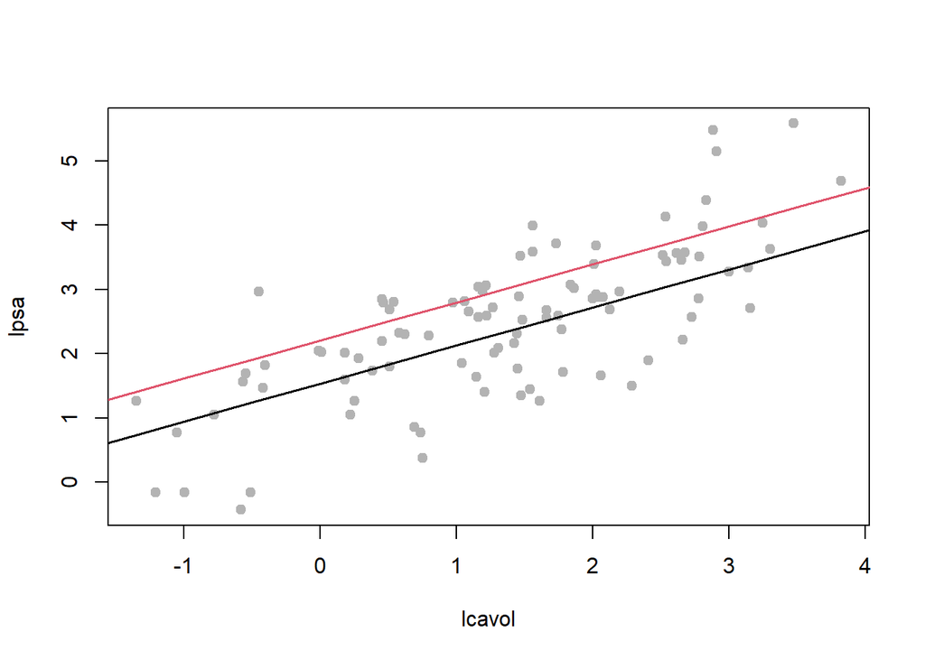

```r
plot(lpsa ~ lcavol, data = prostate, pch = 19, col = "grey70")
nd <- data.frame(lcavol = seq(-2,5,by = 0.5),
                 svi = factor(0))
lines(nd$lcavol, predict(fitCat, newdata = nd), lwd = 1.5)
nd <- data.frame(lcavol = seq(-2,5,by = 0.5),
                 svi = factor(1))
lines(nd$lcavol, predict(fitCat, newdata = nd), col = 2, lwd = 1.5)
```

Abbiamo stimato il seguente modell:

La stima che otteniamo per i due gruppi differiscono per il valore dell’intercetta. Stimiamo lo stesso coefficiente angolare: l’effetto del predittore (`lcavol`) è uguale per tutti i pazienti, sia che `svi = 0` o `svi = 1`

Potremmo quindi chiederci se effettivamente l’effetto del predittore sia diverso nei due gruppi:

$$\text{Se svi = 1:} \ y_i = \beta_0 + \beta_1 x_{i} + \beta_2 (*svi = 1)
+ \beta_3 x_{i}(* svi = 1) = (\beta_0 + \beta_2) + (\beta_1 + \beta_3)
x_{i}$$
$$\text{Se svi = 0:} \ y_i = \beta_0 + \beta_1 x_{i}$$

```r
fitInt <- lm(lpsa ~ lcavol+svi+lcavol:svi, data = prostate)
summary(fitInt)
```

```
##
## Call:
## lm(formula = lpsa ~ lcavol + svi + lcavol:svi, data = prostate)
##
## Residuals:
##     Min      1Q  Median      3Q     Max
## -1.6305 -0.5007  0.1266  0.4886  1.6847
##
## Coefficients:
##             Estimate Std. Error t value Pr(>|t|)
## (Intercept)  1.53970    0.12070  12.757  < 2e-16 ***
## lcavol       0.58640    0.08207   7.145 1.98e-10 ***
## svi1         0.51385    0.67784   0.758    0.450
## lcavol:svi1  0.06479    0.26614   0.243    0.808
## ---
## Signif. codes:  0 '***' 0.001 '**' 0.01 '*' 0.05 '.' 0.1 ' ' 1
##
## Residual standard error: 0.7595 on 93 degrees of freedom
## Multiple R-squared:  0.5806, Adjusted R-squared:  0.5671
## F-statistic: 42.92 on 3 and 93 DF,  p-value: < 2.2e-16
```

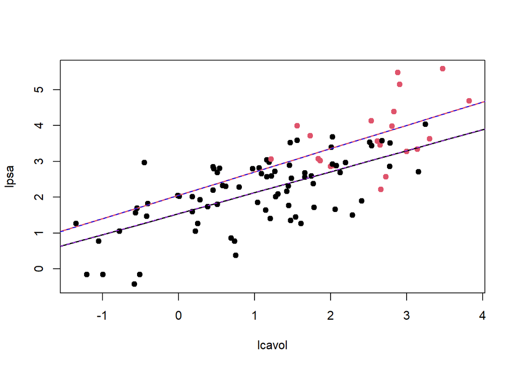

```r
plot(lpsa ~ lcavol, data = prostate, pch = 19,
     col = 1+(prostate$svi == "1"))
nd <- data.frame(lcavol = seq(-2,5,by = 0.5),
                 svi = factor(0))
lines(nd$lcavol, predict(fitInt, newdata = nd), lwd = 1.5)
abline(coef(fitInt)[1], coef(fitInt)[2], lty = 2, col = "purple")
nd <- data.frame(lcavol = seq(-2,5,by = 0.5),
                 svi = factor(1))
lines(nd$lcavol, predict(fitInt, newdata = nd), col = 2, lwd = 1.5)
abline(coef(fitInt)[1]+coef(fitInt)[3],
       coef(fitInt)[2]+coef(fitInt)[4], lty = 2, col = "blue")
```

Il termine che descrive l’interazione (`lcavol:svi1`) è non significativo.

Potremmo anche pensare di stimare due modelli:

```r
summary(lm(lpsa ~ lcavol, data = prostate[prostate$svi == 0,]))
```

```
##
## Call:
## lm(formula = lpsa ~ lcavol, data = prostate[prostate$svi == 0,
##     ])
##
## Residuals:
##     Min      1Q  Median      3Q     Max
## -1.6305 -0.4599  0.1491  0.4807  1.6847
##
## Coefficients:
##             Estimate Std. Error t value Pr(>|t|)
## (Intercept)  1.53970    0.11734   13.12  < 2e-16 ***
## lcavol       0.58640    0.07979    7.35 2.18e-10 ***
## ---
## Signif. codes:  0 '***' 0.001 '**' 0.01 '*' 0.05 '.' 0.1 ' ' 1
##
## Residual standard error: 0.7384 on 74 degrees of freedom
## Multiple R-squared:  0.4219, Adjusted R-squared:  0.4141
## F-statistic: 54.02 on 1 and 74 DF,  p-value: 2.18e-10
```

```r
summary(lm(lpsa ~ lcavol, data = prostate[prostate$svi == 1,]))
```

```
##
## Call:
## lm(formula = lpsa ~ lcavol, data = prostate[prostate$svi == 1,
##     ])
##
## Residuals:
##     Min      1Q  Median      3Q     Max
## -1.5726 -0.5007 -0.1761  0.4886  1.5469
##
## Coefficients:
##             Estimate Std. Error t value Pr(>|t|)
## (Intercept)   2.0536     0.7348   2.795   0.0116 *
## lcavol        0.6512     0.2789   2.335   0.0307 *
## ---
## Signif. codes:  0 '***' 0.001 '**' 0.01 '*' 0.05 '.' 0.1 ' ' 1
##
## Residual standard error: 0.8367 on 19 degrees of freedom
## Multiple R-squared:  0.2229, Adjusted R-squared:  0.182
## F-statistic: 5.451 on 1 and 19 DF,  p-value: 0.03068
```

e otterremmo stime puntuali per i coefficienti molto simili. Tuttavia, in questi due modelli stiamo assumendo che nei due gruppi le varianze siano diverse (e infatti ne otteniamo stime diverse). Inoltre dovremo sempre gestire due modelli diversi per ogni gruppo: questo può diventare laborioso se abbiamo tanti gruppi nel modello.